# Predict Iris Species

2020/7/7

## Introduction

This an APP based on machine learning methods to predict the species of Iris. Users may input the sepal and petal features, and the app will return the predicted species for users. The training dataset is the iris dataset built internally in R.

## Algorithm

The app applies two moedels：  
1.the decision tree model  
2.the random forest model  
Given experiences, the accuracy of these models is higher than the traditional generalized linear regression model.

## Tree Model

Below is a demonstration of the decision tree model.

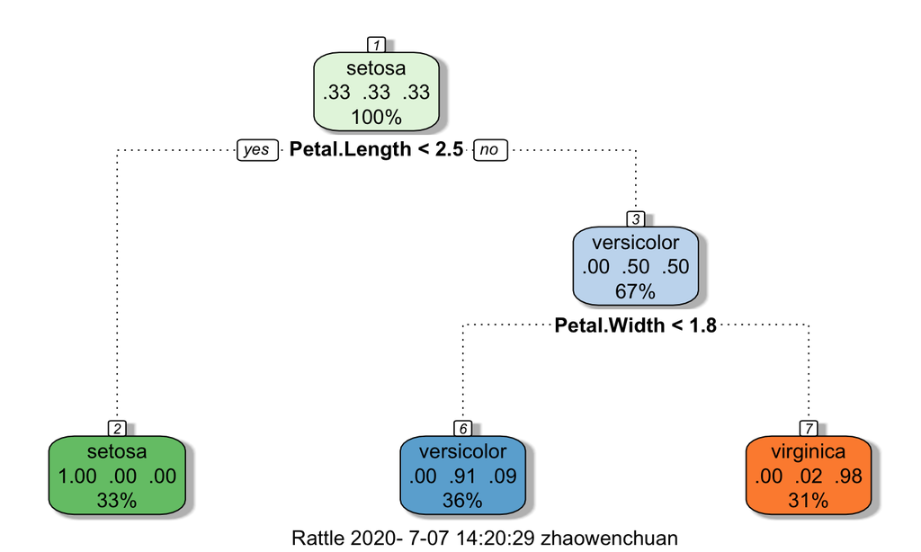

## Usage

First, you can drop the slider to specify the length and width of sepal and petal. The minimum step is 0.1, so it is wise to round the data in one decimal.  
After this, you can decide whether to show the tree model in the result. The tree model shows how the decision tree model predicts the species of iris.  
Finally, don’t forget to click submit as the final step, or the result will not show up.